# Introduction to regression

## A famous motivating example

### (Perhaps surprisingly, this example is still relevant)

[figure not shown]

http://www.nature.com/ejhg/journal/v17/n8/full/ejhg20095a.html

[Predicting height: the Victorian approach beats modern genomics](http://www.wired.com/wiredscience/2009/03/predicting-height-the-victorian-approach-beats-modern-genomics/)

## Recent simply statistics post

(Simply Statistics is a blog by Jeff Leek, Roger Peng and Rafael Irizarry, who wrote this post, link on the image)

[figure not shown]

- “Data supports claim that if Kobe stops ball hogging the Lakers will win more”
- “Linear regression suggests that an increase of 1% in % of shots taken by Kobe results in a drop of 1.16 points (+/- 0.22) in score differential.”
- How was it done? Do you agree with the analysis?

## Questions for this class

- Consider trying to answer the following kinds of questions:
- To use the parents’ heights to predict childrens’ heights.
- To try to find a parsimonious, easily described mean relationship between parent and children’s heights.
- To investigate the variation in childrens’ heights that appears unrelated to parents’ heights (residual variation).
- To quantify what impact genotype information has beyond parental height in explaining child height.
- To figure out how/whether and what assumptions are needed to generalize findings beyond the data in question.
- Why do children of very tall parents tend to be tall, but a little shorter than their parents and why children of very short parents tend to be short, but a little taller than their parents? (This is a famous question called ‘Regression to the mean’.)

## Galton’s Data

- Let’s look at the data first, used by Francis Galton in 1885.
- Galton was a statistician who invented the term and concepts of regression and correlation, founded the journal Biometrika, and was the cousin of Charles Darwin.
- You may need to run `install.packages("UsingR")` if the `UsingR` library is not installed.
- Let’s look at the marginal (parents disregarding children and children disregarding parents) distributions first.
- Parent distribution is all heterosexual couples.
- Correction for gender via multiplying female heights by 1.08.
- Overplotting is an issue from discretization.

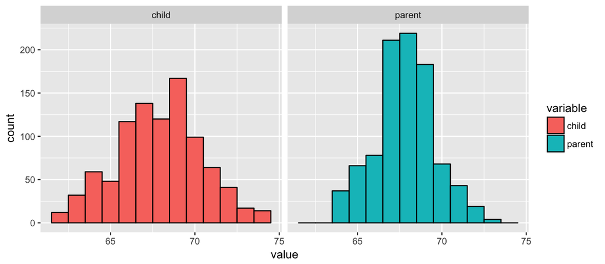

```r
data(galton)
long <- melt(galton)
g <- ggplot(long, aes(x = value, fill = variable))
g <- g + geom_histogram(colour = "black", binwidth=1)
g <- g + facet_grid(. ~ variable)
g
```

## Finding the middle via least squares

- Consider only the children’s heights.
  - How could one describe the “middle”?
  - One definition, let $Y_i$ be the height of child $i$ for $i = 1, \ldots, n = 928$, then define the middle as the value of $\mu$ that minimizes
    $$\sum_{i=1}^n (Y_i - \mu)^2$$
- This is physical center of mass of the histrogram.
- You might have guessed that the answer $\mu = \bar Y$.

## The least squares est. is the empirical mean

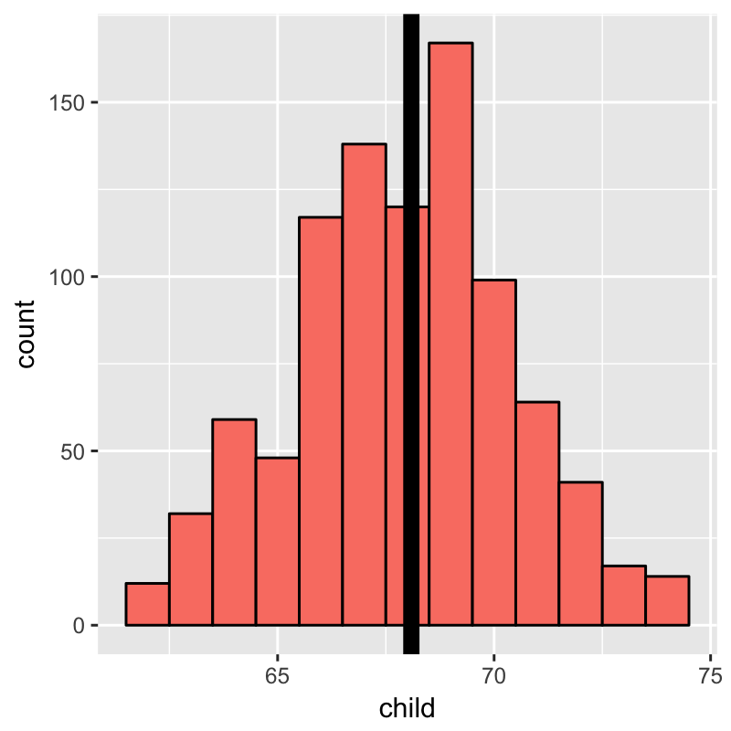

```r
g <- ggplot(galton, aes(x = child)) + geom_histogram(fill = "salmon", colour = "black", binwidth=1)
g <- g + geom_vline(xintercept = mean(galton$child), size = 3)
g
```

### The math follows as:

$$\begin{align}
\sum_{i=1}^n \left(Y_i - \mu\right)^2 & = \
\sum_{i=1}^n \left(Y_i - \bar Y + \bar Y - \mu\right)^2 \\
& = \sum_{i=1}^n \left(Y_i - \bar Y\right)^2 + \
2 \sum_{i=1}^n \left(Y_i - \bar Y\right) \left(\bar Y - \mu\right) +\
\sum_{i=1}^n \left(\bar Y - \mu\right)^2 \\
& = \sum_{i=1}^n \left(Y_i - \bar Y\right)^2 + \
2 \left(\bar Y - \mu\right) \sum_{i=1}^n \left(Y_i - \bar Y\right) +\
\sum_{i=1}^n \left(\bar Y - \mu\right)^2 \\
& = \sum_{i=1}^n \left(Y_i - \bar Y\right)^2 + \
2 \left(\bar Y - \mu\right) \left(\left(\sum_{i=1}^n Y_i\right) -\
n \bar Y\right) +\
\sum_{i=1}^n \left(\bar Y - \mu\right)^2 \\
& = \sum_{i=1}^n \left(Y_i - \bar Y\right)^2 + \
\sum_{i=1}^n \left(\bar Y - \mu\right)^2\\
& \geq \sum_{i=1}^n \left(Y_i - \bar Y\right)^2 \
\end{align}$$

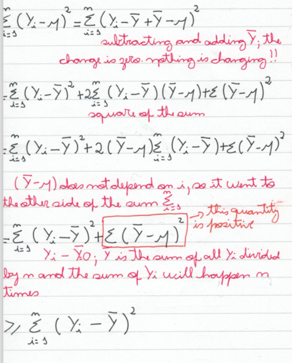

## Comparing childrens’ heights and their parents’ heights

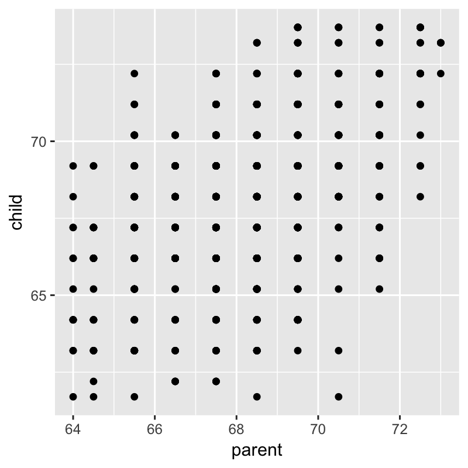

```r
ggplot(galton, aes(x = parent, y = child)) + geom_point()
```

Size of point represents number of points at that (X, Y) combination.

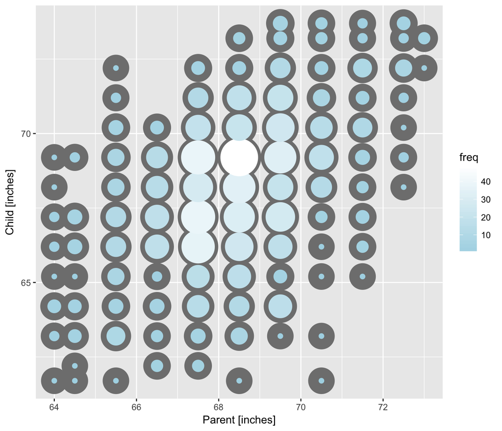

## Regression through the origin

- Suppose that $X_i$ are the parents’ heights.
- Consider picking the slope $\beta$ that minimizes
  $$\sum_{i=1}^n (Y_i - X_i \beta)^2$$
- This is exactly using the origin as a pivot point picking the line that minimizes the sum of the squared vertical distances of the points to the line
- Use R studio’s manipulate function to experiment
- Subtract the means so that the origin is the mean of the parent and children’s heights

```r
y <- galton$child - mean(galton$child)
x <- galton$parent - mean(galton$parent)
freqData <- as.data.frame(table(x, y))
names(freqData) <- c("child", "parent", "freq")
freqData$child <- as.numeric(as.character(freqData$child))
freqData$parent <- as.numeric(as.character(freqData$parent))
myPlot <- function(beta){
    g <- ggplot(filter(freqData, freq > 0), aes(x = parent, y = child))
    g <- g  + scale_size(range = c(2, 20), guide = "none" )
    g <- g + geom_point(colour="grey50", aes(size = freq+20, show_guide = FALSE))
    g <- g + geom_point(aes(colour=freq, size = freq))
    g <- g + scale_colour_gradient(low = "lightblue", high="white")
    g <- g + geom_abline(intercept = 0, slope = beta, size = 3)
    mse <- mean( (y - beta * x) ^2 )
    g <- g + ggtitle(paste("beta = ", beta, "mse = ", round(mse, 3)))
    g
}
manipulate(myPlot(beta), beta = slider(0.6, 1.2, step = 0.02))
```

## The solution

### In the next few lectures we’ll talk about why this is the solution

```r
lm(I(child - mean(child))~ I(parent - mean(parent)) - 1, data = galton)
```

```
Call:
lm(formula = I(child - mean(child)) ~ I(parent - mean(parent)) -
    1, data = galton)

Coefficients:
I(parent - mean(parent))
                  0.6463
```

```r
# centered child and parents heigh (subtracting the mean)
# and -1 means not using the intercept, forcing 0,0
```

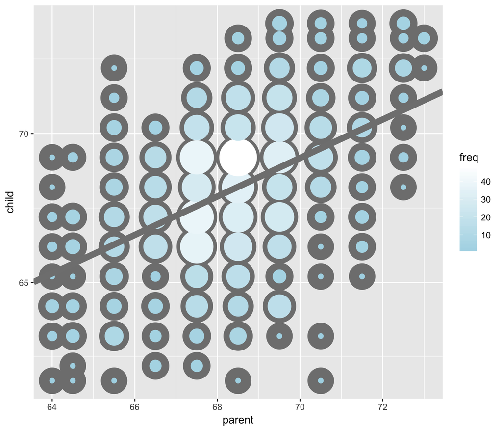

## Exercises

1. Consider the dataset given by `x=c(0.725,0.429,-0.372 ,0.863)`. What value of $\mu$ minimizes $sum((x - \mu)^2)$?

```
[1] 0.41125
```

2. Reconsider the previous question. Suppose that weights were given, `w = c(2, 2, 1, 1)` so that we wanted to minimize $sum(w * (x - \mu) ^ 2)$ for $\mu$. What value would we obtain?

```r
w = c(2, 2, 1, 1)
x=c(0.725,0.429,-0.372 ,0.863)
# when I have weigths:
# sum(wi * Xi) / sum(wi)

sum(w  * x) / sum(w)
```

```
[1] 0.4665
```

3. Take the Galton data and obtain the regression through the origin slope estimate where the centered parental height is the outcome and the child’s height is the predictor

```r
head(galton)
```

```
  child parent
1  61.7   70.5
2  61.7   68.5
3  61.7   65.5
4  61.7   64.5
5  61.7   64.0
6  62.2   67.5
```

```r
y = galton$parent
x = galton$child
y_centered = y - mean(y)
x_centered = x - mean(x)

# the regression coefficient is:
sum (y_centered * x_centered) / (sum(x_centered^2))
```

```
[1] 0.3256475
```

```r
# or
lm(y_centered ~ x_centered - 1)
```

```
Call:
lm(formula = y_centered ~ x_centered - 1)

Coefficients:
x_centered
    0.3256
```

```r
# if
# I will get the same slope
# but I will have an intercept
lm(y ~ x)
```

```
Call:
lm(formula = y ~ x)

Coefficients:
(Intercept)            x
    46.1353       0.3256
```